# Multi-class Classification: Softmax

## Pytorch

Created on JupyterLab

## Table of Contents

- Make some Data
- Build a Softmax Classifier
- Define Softmax, Criterion Function, Optimizer, and Train the Model
- Analyze Results

**The argmax function returns the index corresponding to the largest value in a sequence of numbers.**

Logistic regression can be used for two classes, but how about if we wanted to solve a multi-class problem?

Consider the following classes: we have Y equals 0as cat, Y equals one 1 dog, we have Y equals 2 for fish.

Instead of using one plane to classify the data, **we will use one plane for each class**. In this case, we have **three equations representing three classes**, but we can generalize to any number of classes. The the lines defined by the equations must split the classes. **The equations would be: z0 = w0x+b0, z1 = w1x+b1, z2 = w2x+b2.**

If the input is in the dog region (defined by the equation), the value of z0 corresponding to the equation zero is the largest. This is where the dog plane has a higher value than the other regions (cat and fish). Therefore, anything in this region will be in class zero. **Thus, we use the planes to classify the unknown point. We calculate the output of the plane and apply the argmax function.**

The reason the function is called SoftMax, since the **actual distances**, that is **dot products for each input vector with the parameters is converted to probabilities**. Training for SoftMax is almost identical to logistic regression.

The softmax function converts the actual distances i.e. dot products of $x$ with each of the parameters $\theta_i$ for the $K$ classes. This is converted to probabilities using the following :

$softmax(x,i) = \frac{e^{ \theta_i^T \bf x}}{\sum_{j=1}^K e^{\theta_j^T x}} $

The training procedure is almost identical to logistic regression. Consider the three-class example where $y \in \{0,1,2\}$ we would like to classify $x_1$. We can use the softmax function to generate a probability of how likely the sample belongs to each class:

$[softmax(x_1,0),softmax(x_1,1),softmax(x_1,2)]=[0.97,0.2,0.1]$

The index of each probability is the same as the class. We can make a prediction using the argmax function:

$\hat{y}=argmax_i \{softmax(x,i)\}$

For the above example, we can make a prediction as follows:

$\hat{y}=argmax_i \{[0.97,0.2,0.1]\}=0$

## Preparation

We'll need the following libraries

```python
#!pip3 install torch torchvision torchaudio
```

```python
# Using the following line code to install the torchvision library
# !conda install -y torchvision
# PyTorch Library
import torch
# PyTorch Neural Network
import torch.nn as nn
# Allows us to transform data
import torchvision.transforms as transforms
# Allows us to get the digit dataset
import torchvision.datasets as dsets
# Creating graphs
import matplotlib.pylab as plt
# Allows us to use arrays to manipulate and store data
import numpy as np
```

Use the following function to plot out the parameters of the Softmax function:

```python
# The function to plot parameters

def PlotParameters(model):
    W = model.state_dict()['linear.weight'].data
    w_min = W.min().item()
    w_max = W.max().item()
    fig, axes = plt.subplots(2, 5)
    fig.subplots_adjust(hspace=0.01, wspace=0.1)
    for i, ax in enumerate(axes.flat):
        if i < 10:

            # Set the label for the sub-plot.
            ax.set_xlabel("class: {0}".format(i))

            # Plot the image.
            ax.imshow(W[i, :].view(28, 28), vmin=w_min, vmax=w_max, cmap='seismic')

            ax.set_xticks([])
            ax.set_yticks([])

        # Ensure the plot is shown correctly with multiple plots
        # in a single Notebook cell.
    plt.show()
```

Use the following function to visualize the data:

```python
# Plot the data
def show_data(data_sample):
    plt.imshow(data_sample[0].numpy().reshape(28, 28), cmap='gray')
    plt.title('y = ' + str(data_sample[1]))
```

## Make Some Data

Load the *training* dataset by setting the parameters `train` to `True` and convert it to a tensor by placing a transform object in the argument `transform`.

```python
# Create and print the training dataset
train_dataset = dsets.MNIST(root='./data', train=True, download=True, transform=transforms.ToTensor())
print("Print the training dataset:\n ", train_dataset)
```

```
Print the training dataset:
  Dataset MNIST
    Number of datapoints: 60000
    Root location: ./data
    Split: Train
    StandardTransform
Transform: ToTensor()
```

```python
# Create and print the validation dataset
validation_dataset = dsets.MNIST(root='./data', download=True, transform=transforms.ToTensor())
print("Print the validation dataset:\n ", validation_dataset)
```

```
Print the validation dataset:
  Dataset MNIST
    Number of datapoints: 60000
    Root location: ./data
    Split: Train
    StandardTransform
Transform: ToTensor()
```

We can access the data by indexing the train_dataset and test_dataset

```
First Image and Label
```

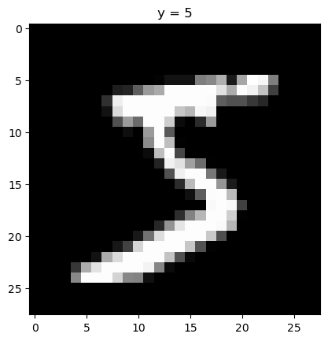

```python
# Print the first image and label
print("First Image and Label")
show_data(train_dataset[0])
```

Each element in the rectangular tensor corresponds to a number which represents a pixel intensity, as demonstrated by the following image:

[figure not shown]

In this image, the values are inverted i.e black represents white.

Print out the label of the fourth element:

```python
# Print the label
print("The label: ", train_dataset[3][1])
```

```
The label:  1
```

The result shows the number in the image is 1

Plot the fourth sample:

```
The image:
```

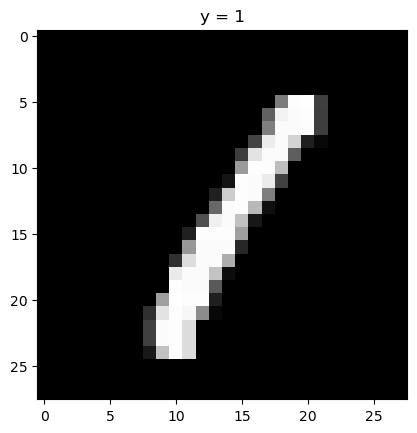

```python
# Plot the image
print("The image: ")
show_data(train_dataset[3])
```

You see that it is a 1. Now, plot the third sample:

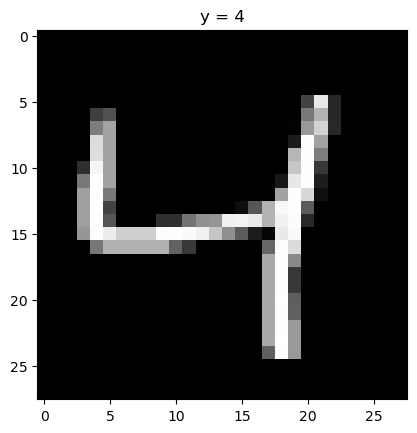

```python
# Plot the image
show_data(train_dataset[2])
```

## Build a Softmax Classifer

Build a Softmax classifier class:

```python
# Define softmax classifier class
# Inherits nn.Module which is the base class for all neural networks
class SoftMax(nn.Module):

    # Constructor
    def __init__(self, input_size, output_size):
        super(SoftMax, self).__init__()
        # Creates a layer of given input size and output size
        self.linear = nn.Linear(input_size, output_size)

    # Prediction
    def forward(self, x):
        # Runs the x value through the single layers defined above
        z = self.linear(x)
        return z
```

The Softmax function requires vector inputs. Note that the vector shape is 28x28.

```python
# Print the shape of the training dataset
train_dataset[0][0].shape
```

```
torch.Size([1, 28, 28])
```

Flatten the tensor as shown in this image:

[figure not shown]

The size of the tensor is now 784.

[figure not shown]

Set the input size and output size:

```python
# Set input size and output size
input_dim = 28 * 28
output_dim = 10
```

## Define the Softmax Classifier, Criterion Function, Optimizer, and Train the Model

```python
# Create the model
# Input dim is 28*28 which is the image converted to a tensor
# Output dim is 10 because there are 10 possible digits the image can be
model = SoftMax(input_dim, output_dim)
print("Print the model:\n ", model)
```

```
Print the model:
  SoftMax(
  (linear): Linear(in_features=784, out_features=10, bias=True)
)
```

View the size of the model parameters:

```python
# Print the parameters
print('W: ',list(model.parameters())[0].size())
print('b: ',list(model.parameters())[1].size())
```

```
W:  torch.Size([10, 784])
b:  torch.Size([10])
```

You can convert the model parameters for each class to a rectangular grid:

[figure not shown]

Plot the model parameters for each class as a square image:

```python
# Plot the model parameters for each class
# Since the model has not been trained yet the parameters look random
# PlotParameters(model)
```

We can make a prediction

```python
# First we get the X value of the first image
X = train_dataset[0][0]
# We can see the shape is 1 by 28 by 28, we need it to be flattened to 1 by 28 * 28 (784)
print(X.shape)
X = X.view(-1, 28*28)
print(X.shape)
# Now we can make a prediction, each class has a value, and the higher it is the more confident the model is that it is that digit
model(X)
```

```
torch.Size([1, 28, 28])
torch.Size([1, 784])
```

```
tensor([[ 0.5539, -0.2030,  0.3239, -0.3437,  0.1403,  0.3119,  0.0901, -0.0058,
         -0.1635, -0.1616]], grad_fn=<AddmmBackward0>)
```

Define the learning rate, optimizer, criterion, data loader:

```python
# Define the learning rate, optimizer, criterion, and data loader
learning_rate = 0.1
# The optimizer will updates the model parameters using the learning rate
optimizer = torch.optim.SGD(model.parameters(), lr=learning_rate)
# The criterion will measure the loss between the prediction and actual label values
# This is where the SoftMax occurs, it is built into the Criterion Cross Entropy Loss
criterion = nn.CrossEntropyLoss()
# Created a training data loader so we can set the batch size
train_loader = torch.utils.data.DataLoader(dataset=train_dataset, batch_size=100)
# Created a validation data loader so we can set the batch size
validation_loader = torch.utils.data.DataLoader(dataset=validation_dataset, batch_size=5000)
```

### How Cross Entropy Loss uses SoftMax

We have X which is the X values of the first image and `actual` which is the the digit class the image belongs to. The output `model_output` is the value the model assigns to each class for that image.

```python
model_output = model(X)
actual = torch.tensor([train_dataset[0][1]])

#show_data(train_dataset[0])
print("Output: ", model_output)
print("Actual:", actual)
```

```
Output:  tensor([[ 0.5539, -0.2030,  0.3239, -0.3437,  0.1403,  0.3119,  0.0901, -0.0058,
         -0.1635, -0.1616]], grad_fn=<AddmmBackward0>)
Actual: tensor([5])
```

The criterion will take these values and return a loss

```python
criterion(model_output, actual)
```

```
tensor(2.0817, grad_fn=<NllLossBackward0>)
```

Cross Entropy Loss takes probabilities and we can see that `model_output` are not probabilities, this is where softmax comes in

```python
softmax = nn.Softmax(dim=1)
probability = softmax(model_output)
print(probability)
```

```
tensor([[0.1589, 0.0745, 0.1262, 0.0647, 0.1050, 0.1247, 0.0999, 0.0908, 0.0775,
         0.0777]], grad_fn=<SoftmaxBackward0>)
```

**Now that we have probabilities, we can just calculate the negative log of the probability of the class that this image belongs to. The image belongs to the target class so we calculate the negative log of the probability at the target index.**

```python
-1*torch.log(probability[0][actual])
```

```
tensor([2.0817], grad_fn=<MulBackward0>)
```

As you can see the result above matches the result of the criterion, this is how Cross Entropy Loss uses Softmax.

### Train

Train the model and determine validation accuracy **(should take a few minutes)**:

```python
# Number of times we train our model useing the training data
n_epochs = 10
# Lists to keep track of loss and accuracy
loss_list = []
accuracy_list = []
# Size of the validation data
N_test = len(validation_dataset)

# Function to train the model based on number of epochs
def train_model(n_epochs):
    # Loops n_epochs times
    for epoch in range(n_epochs):
        # For each batch in the train loader
        for x, y in train_loader:
            # Resets the calculated gradient value, this must be done each time as it accumulates if we do not reset
            optimizer.zero_grad()
            # Makes a prediction based on the image tensor
            z = model(x.view(-1, 28 * 28))
            # Calculates loss between the model output and actual class
            loss = criterion(z, y)
            # Calculates the gradient value with respect to each weight and bias
            loss.backward()
            # Updates the weight and bias according to calculated gradient value
            optimizer.step()

        # Each epoch we check how the model performs with data it has not seen which is the validation data, we are not training here
        correct = 0
        # For each batch in the validation loader
        for x_test, y_test in validation_loader:
            # Makes prediction based on image tensor
            z = model(x_test.view(-1, 28 * 28))
            # Finds the class with the higest output
            _, yhat = torch.max(z.data, 1)
            # Checks if the prediction matches the actual class and increments correct if it does
            correct += (yhat == y_test).sum().item()
        # Calculates the accuracy by dividing correct by size of validation dataset
        accuracy = correct / N_test
        # Keeps track loss
        loss_list.append(loss.data)
        # Keeps track of the accuracy
        accuracy_list.append(accuracy)

# Function call
train_model(n_epochs)
```

## Analyze Results

Plot the loss and accuracy on the validation data:

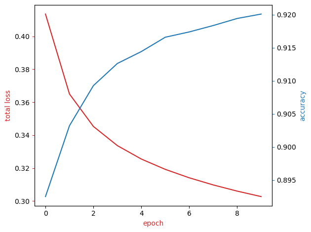

```python
# Plot the loss and accuracy

fig, ax1 = plt.subplots()
color = 'tab:red'
ax1.plot(loss_list,color=color)
ax1.set_xlabel('epoch',color=color)
ax1.set_ylabel('total loss',color=color)
ax1.tick_params(axis='y', color=color)

ax2 = ax1.twinx()
color = 'tab:blue'
ax2.set_ylabel('accuracy', color=color)
ax2.plot( accuracy_list, color=color)
ax2.tick_params(axis='y', color=color)
fig.tight_layout()
```

View the results of the parameters for each class after the training. You can see that they look like the corresponding numbers.

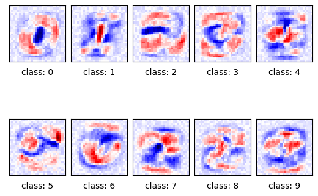

```python
# Plot the parameters
PlotParameters(model)
```

We Plot the first five misclassified samples and the probability of that class.

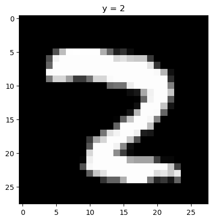

```
yhat: tensor([7])
probability of class  0.677849531173706
```

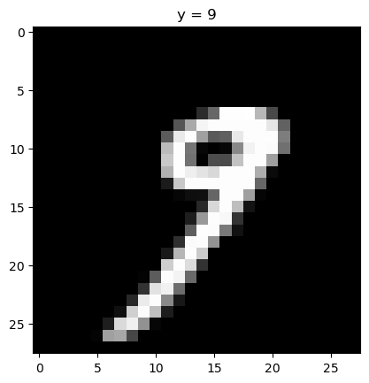

```
yhat: tensor([7])
probability of class  0.7129123210906982
```

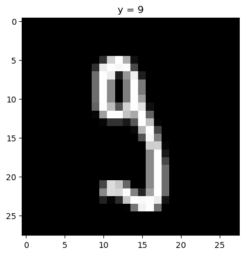

```
yhat: tensor([5])
probability of class  0.7302111983299255
```

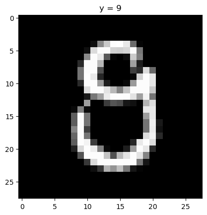

```
yhat: tensor([8])
probability of class  0.36540937423706055
```

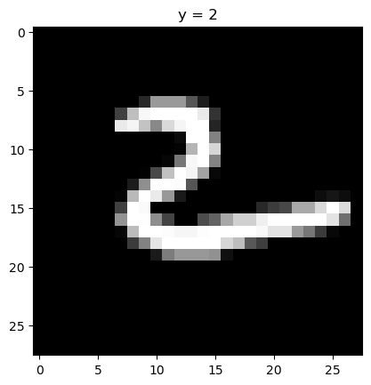

```
yhat: tensor([6])
probability of class  0.5140953660011292
```

```python
# Plot the misclassified samples
Softmax_fn=nn.Softmax(dim=-1)
count = 0
for x, y in validation_dataset:
    z = model(x.reshape(-1, 28 * 28))
    _, yhat = torch.max(z, 1)
    if yhat != y:
        show_data((x, y))
        plt.show()
        print("yhat:", yhat)
        print("probability of class ", torch.max(Softmax_fn(z)).item())
        count += 1
    if count >= 5:
        break
```

We plot the first five correctly classified samples and the probability of that class. We see the probability is much larger.

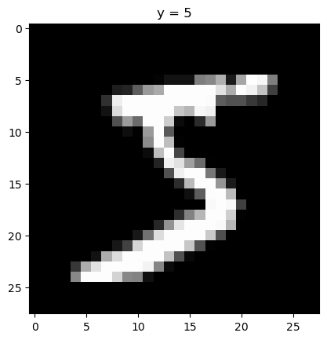

```
yhat: tensor([5])
probability of class  0.8565948605537415
```

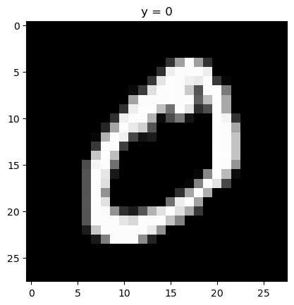

```
yhat: tensor([0])
probability of class  0.9997077584266663
```

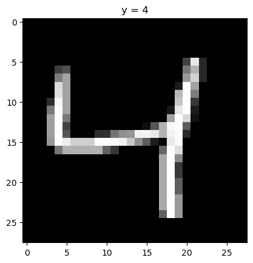

```
yhat: tensor([4])
probability of class  0.8669520616531372
```

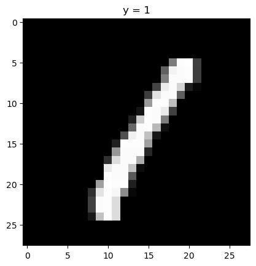

```
yhat: tensor([1])
probability of class  0.9649670124053955
```

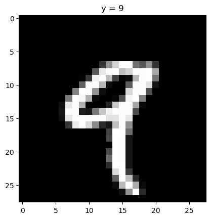

```
yhat: tensor([9])
probability of class  0.9279288649559021
```

```python
# Plot the classified samples
Softmax_fn=nn.Softmax(dim=-1)
count = 0
for x, y in validation_dataset:
    z = model(x.reshape(-1, 28 * 28))
    _, yhat = torch.max(z, 1)
    if yhat == y:
        show_data((x, y))
        plt.show()
        print("yhat:", yhat)
        print("probability of class ", torch.max(Softmax_fn(z)).item())
        count += 1
    if count >= 5:
        break
```

# Authors' rights

Machine Learning with Python course by IBM on Coursera: https://www.coursera.org/learn/machine-learning-with-python/

Completed and modified by Mathilde Marie Duville as part of the IBM Artificial Intelligence Engineering Professional Certificate and corresponding IBM badges. Please, follow the subsequent links to confirm the accreditation:

https://www.coursera.org/account/accomplishments/professional-cert/KSLW773DAATP?utm_source=link&utm_medium=certificate&utm_content=cert_image&utm_campaign=sharing_cta&utm_product=prof

https://www.credly.com/users/mathilde-marie-duville/badges

Author: [Joseph Santarcangelo](https://www.linkedin.com/in/joseph-s-50398b136/) has a PhD in Electrical Engineering, his research focused on using machine learning, signal processing, and computer vision to determine how videos impact human cognition. Joseph has been working for IBM since he completed his PhD.

Other contributors: [Michelle Carey](https://www.linkedin.com/in/michelleccarey/), [Mavis Zhou](https://www.linkedin.com/in/jiahui-mavis-zhou-a4537814a)

## Change Log

| Date (YYYY-MM-DD) | Version | Changed By | Change Description |
| --- | --- | --- | --- |
| 2020-09-23 | 2.0 | Shubham | Migrated Lab to Markdown and added to course repo in GitLab |